# GGIS 224 - Lab 6

Jonathan Bernard Widjajakusuma, Environmental Data Science @UIUC

2/24/2024

## Overview

In this lab you’ll explore the pattern of spatial clustering (autocorrelation) in the Chicago area using the ChiVes dataset.

Before starting the lab, make sure you’ve gone through [3. Spatial Cluster Detection](https://makosak.github.io/Intro2RSpatialMed/05-LISA.html).

You will have a lot of flexibility in this lab, so please treat it as a mini-project. Follow the instruction below to explore the lab, and enjoy!

## Environment Setup

Load up all libraries needed for this lab.

```r
library(sf)
library(dplyr)
library(tmap)
library(rgeoda)
```

Read in the Chicago census tract level data (chives-data.geojson) that we used in Lab 3.

```r
chitracts = st_read("/Users/jonathanbernard/Desktop/UIUC/Spring 2024/GGIS 224/GGIS224/Labs/Lab6/chives-data.geojson")
```

Recall that the Chives dataset was downloaded from [the ChiVes project website](https://chichives.com).

ChiVes is a collaborative project that integrates and visualizes data in Chicago. A handful of key metrics, such as tree cover, air pollution estimates, heat island effects, traffic volumes, and social vulnerability index, help to reveal where in the city people face particular challenges as we work towards a healthier Chicago. You will need to review the Data page to understand the variable names and definitions. Check out what attributes are available and what they define and measure in [the ChiVes project website](https://chichives.com).

For your submission, please extend this R Markdown file to explore at least one attribute/variable given in chives-data, and calculate and map its Local Moran’s I (LISA) and the associated significance test. Refer to the scripts in [3. Spatial Cluster Detection](https://makosak.github.io/Intro2RSpatialMed/05-LISA.html) for an example. Let’s use the default settings of 999 permutations and a p-value of 0.05; but since there are 999 permutations, it allows you to test the significance with the smallest p-value of 0.001.

Feel free to compare the result using a rook contiguity weight and the result using a queen contiguity weight (with either 1 or 2 orders).

Refer to the rgeoda tutorial for more information on spatial weights: https://geodacenter.github.io/rgeoda/articles/rgeoda_tutorial.html#spatial-weights.

**Your code should include:** 1. A choropleth map determining which Chives variable you want to explore for spatial autocorrelation (1 pt). 2. A spatial contiguity weight matrix necessary for calculating LISA (1 pt). 3. LISA calculation (2 pts). 4. A map displaying LISA results (2 pts). 5. A map displaying LISA significance test (certainty check) results (2 pts).

**Following your code and maps, answer the following discussions:** 1. What is your hypothesis of the spatial autocorrelation pattern of the attribute you explored? Do you think your calculated result overall supports your hypothesis? (1 pt). 2. Did you identify any interesting hot spots and cold spots? And, did you find any census tracts that appear to be outliers? Given your best understanding of the local environments, why do you think those spots and outliers occur? (1 pt).

[1 bonus point] Calculate the global Moran’s I. How do the LISA (local Moran’s I) values compare? Do you see any advantage of using LISA? (only need to display a value, no map necessary)

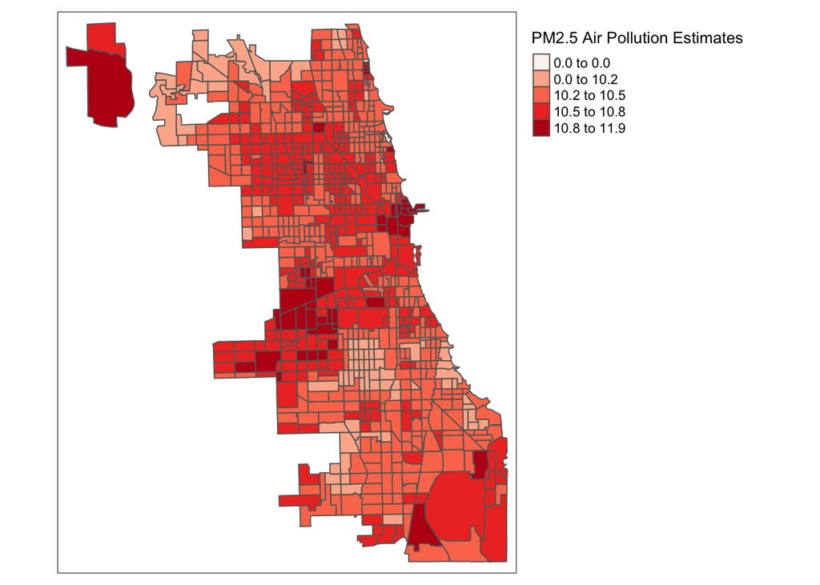

```r
# plotting the choropleth map of PM2.5 air pollution estimates
tm_shape(chitracts) +
  tm_polygons("nn_q3_pm2_5", style="jenks", palette="Reds", title="PM2.5 Air Pollution Estimates") +
  tm_layout(legend.outside = TRUE, legend.outside.position = "right")
```

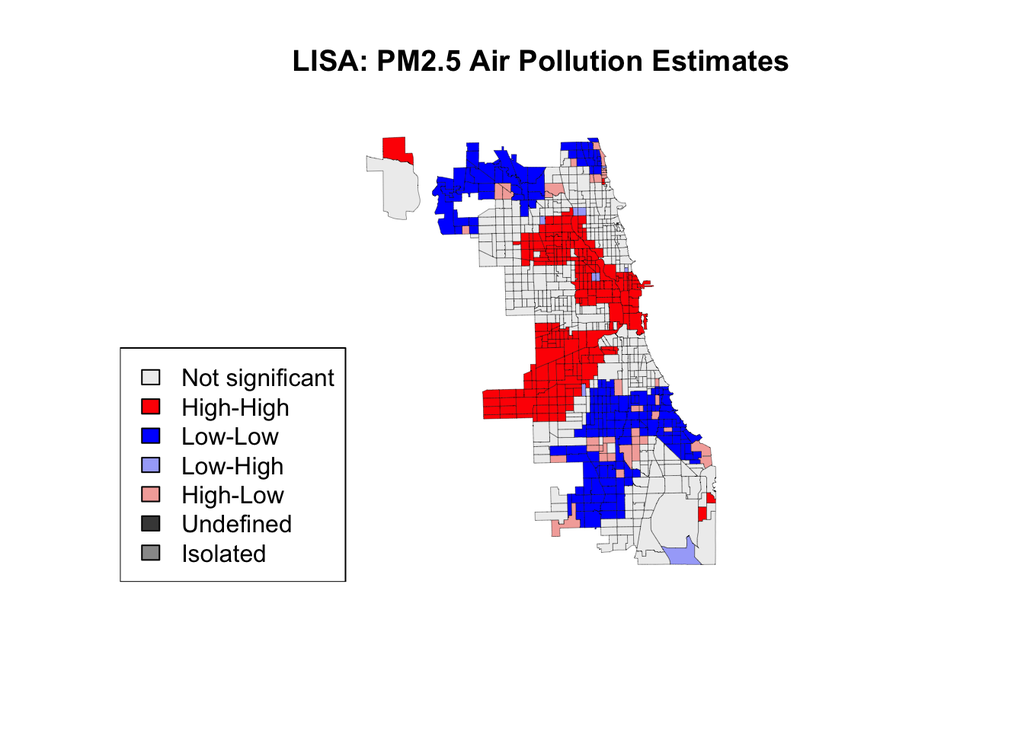

```r
# calculate the spatial weights
w_rook <- rook_weights(chitracts)
w_queen <- queen_weights(chitracts, order = 2, include_lower_order = TRUE)

# convert the PM2.5 data as a numeric vector for LISA calculation
pm25_data <- as.numeric(chitracts[['nn_q3_pm2_5']])

# calculating LISA for the PM2.5 air pollution estimates using queen contiguity weights
lisa_pm25_queen <- local_moran(w_queen, chitracts['nn_q3_pm2_5'], permutations = 999)

# extract and visualize LISA clusters
lisa_colors_queen <- lisa_colors(lisa_pm25_queen)
lisa_labels_queen <- lisa_labels(lisa_pm25_queen)
lisa_clusters_queen <- lisa_clusters(lisa_pm25_queen)

plot(st_geometry(chitracts),
     col=sapply(lisa_clusters_queen, function(x){return(lisa_colors_queen[[x+1]])}),
     lwd=0.2)
title(main = "LISA: PM2.5 Air Pollution Estimates")
legend('bottomleft', legend = lisa_labels_queen, fill = lisa_colors_queen)
```

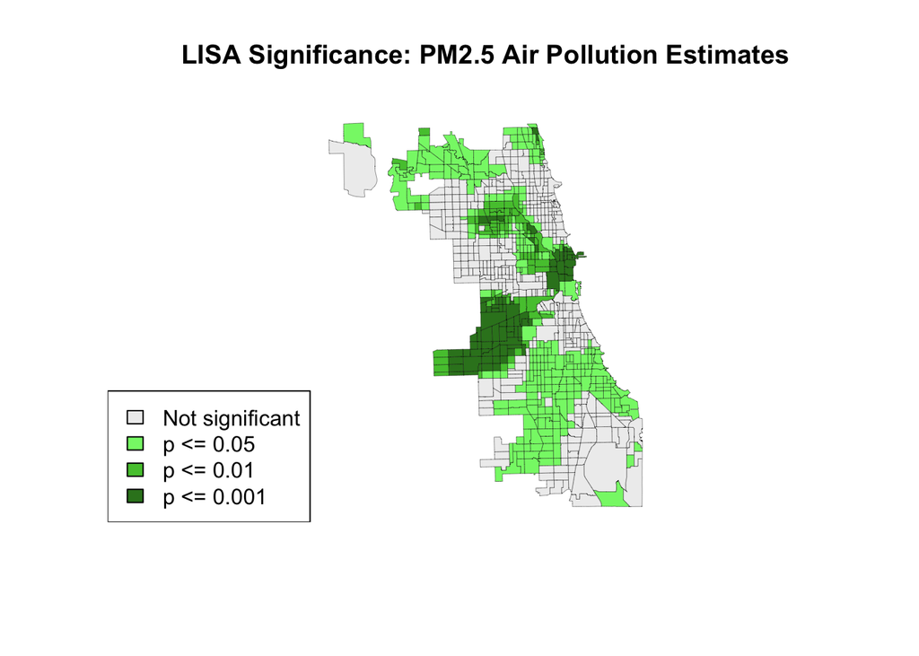

```r
# extract and visualize significance levels
lisa_p_queen <- lisa_pvalues(lisa_pm25_queen)
p_labels <- c("Not significant", "p <= 0.05", "p <= 0.01", "p <= 0.001")
p_colors <- c("#eeeeee", "#84f576", "#53c53c", "#348124")

plot(st_geometry(chitracts),
     col=sapply(lisa_p_queen, function(x){
       if (x <= 0.001) return(p_colors[4])
       else if (x <= 0.01) return(p_colors[3])
       else if (x <= 0.05) return(p_colors[2])
       else return(p_colors[1])
     }),
     , lwd=0.2)
title(main = "LISA Significance: PM2.5 Air Pollution Estimates")
legend('bottomleft', legend = p_labels, fill = p_colors)
```

Your discussion.

1. Hypothesis My hypothesis is that industrial areas and heavy traffic areas would have a significantly higher hot spots due to the higher PM2.5 emissions. On the other hand, areas with less traffic and industrial activity will have more cold spots. The Lisa results supports this hypothesis as significant clustering of high values which are hot spots are around the industrial zones, with lower values which are cold spots in the green dominant areas. There are not really interesting spots as the pattern is quite clear and obvious.
2. Hot Spots and Cold Spots The hot spots which have high levels of PM2.5 are concentrated in areas with industrial zones and area of dense traffic. On the other hand the cold spots which have low levels of PM2.5 are usually remote and residential areas which generally means they have less industrial activity. There are some outliers in which PM2.5 levels are significantly higher than its surrounding. I think there could be smaller industrial operations, or small areas where all traffic converge causing significant congestion, therefore causing a spike in the PM2.5 levels. —

Render your R Markdown document by clicking on the “Knit” option in RStudio. The .html output should include your scripts, calculations, maps, and your text discussion. Upload the .html file to your assignment submission.

.